# Untitled

Seema Rani Kanuri

December 21, 2019

## Case Study

Data Set Information:

The data is related with direct marketing campaigns of a Portuguese banking institution. The marketing campaigns were based on phone calls. Often, more than one contact to the same client was required, in order to access if the product (bank term deposit) would be (‘yes’) or not (‘no’) subscribed.

There are four datasets: 1) bank-additional-full.csv with all examples (41188) and 20 inputs, ordered by date (from May 2008 to November 2010), very close to the data analyzed in [Moro et al., 2014] 2) bank-additional.csv with 10% of the examples (4119), randomly selected from 1), and 20 inputs. 3) bank-full.csv with all examples and 17 inputs, ordered by date (older version of this dataset with less inputs). 4) bank.csv with 10% of the examples and 17 inputs, randomly selected from 3 (older version of this dataset with less inputs).

The smallest datasets are provided to test more computationally demanding machine learning algorithms (e.g., SVM). The classification goal is to predict if the client will subscribe (yes/no) a term deposit (variable y).

Methodology Step 1: Business Problem Step 2: Analytics Objective Step 3: Data Preparation

```
## # A tibble: 6 x 21
##     age       job marital   education default housing  loan   contact month
##   <int>     <chr>   <chr>       <chr>   <chr>   <chr> <chr>     <chr> <chr>
## 1    56 housemaid married    basic.4y      no      no    no telephone   may
## 2    57  services married high.school unknown      no    no telephone   may
## 3    37  services married high.school      no     yes    no telephone   may
## 4    40    admin. married    basic.6y      no      no    no telephone   may
## 5    56  services married high.school      no      no   yes telephone   may
## 6    45  services married    basic.9y unknown      no    no telephone   may
## # ... with 12 more variables: day_of_week <chr>, duration <int>,
## #   campaign <int>, pdays <int>, previous <int>, poutcome <chr>,
## #   emp.var.rate <dbl>, cons.price.idx <dbl>, cons.conf.idx <dbl>,
## #   euribor3m <dbl>, nr.employed <int>, y <chr>
```

## Descriptive Data Analaysis

```r
sapply(bank_additional_full,typeof)
```

```
##            age            job        marital      education        default
##      "integer"    "character"    "character"    "character"    "character"
##        housing           loan        contact          month    day_of_week
##    "character"    "character"    "character"    "character"    "character"
##       duration       campaign          pdays       previous       poutcome
##      "integer"      "integer"      "integer"      "integer"    "character"
##   emp.var.rate cons.price.idx  cons.conf.idx      euribor3m    nr.employed
##       "double"       "double"       "double"       "double"      "integer"
##              y
##    "character"
```

```r
library(Hmisc)
describe(bank_additional_full)
```

```
## bank_additional_full
##
##  21  Variables      41188  Observations
## --------------------------------------------------------------------------------
## age
##        n  missing distinct     Info     Mean      Gmd      .05      .10
##    41188        0       78    0.999    40.02    11.57       26       28
##      .25      .50      .75      .90      .95
##       32       38       47       55       58
##
## lowest : 17 18 19 20 21, highest: 91 92 94 95 98
## --------------------------------------------------------------------------------
## job
##        n  missing distinct
##    41188        0       12
##
## admin. (10422, 0.253), blue-collar (9254, 0.225), entrepreneur (1456, 0.035),
## housemaid (1060, 0.026), management (2924, 0.071), retired (1720, 0.042),
## self-employed (1421, 0.035), services (3969, 0.096), student (875, 0.021),
## technician (6743, 0.164), unemployed (1014, 0.025), unknown (330, 0.008)
## --------------------------------------------------------------------------------
## marital
##        n  missing distinct
##    41188        0        4
##
## Value      divorced  married   single  unknown
## Frequency      4612    24928    11568       80
## Proportion    0.112    0.605    0.281    0.002
## --------------------------------------------------------------------------------
## education
##        n  missing distinct
##    41188        0        8
##
## basic.4y (4176, 0.101), basic.6y (2292, 0.056), basic.9y (6045, 0.147),
## high.school (9515, 0.231), illiterate (18, 0.000), professional.course (5243,
## 0.127), university.degree (12168, 0.295), unknown (1731, 0.042)
## --------------------------------------------------------------------------------
## default
##        n  missing distinct
##    41188        0        3
```

[output cut: 126 more lines]

```
##        n  missing distinct     Info     Mean      Gmd
##     7763    33425        1        0     5191        0
##
## Value      5191
## Frequency  7763
## Proportion    1
## --------------------------------------------------------------------------------
## y
##        n  missing distinct
##    41188        0        2
##
## Value         no   yes
## Frequency  36548  4640
## Proportion 0.887 0.113
## --------------------------------------------------------------------------------
```

# Issues

There are many ‘unknown’ value in the job , education,housing,loan and default feature Preprocessing required to fill unknown values

The data is imbalanced

# Explorartory Data Analaysis

Adding a unique identifier foe each customerid for future

# Replacing the unknow / 999 to NA

```r
bank_additional_full$pdays[bank_additional_full$pdays == 999] <- NA
bank_additional_full[,c(2:7)][bank_additional_full[,c(2:7)] == "unknown"] <- NA
```

# Check number of na in dataset

```r
colSums(is.na.data.frame(bank_additional_full))
```

```
##            age            job        marital      education        default
##              0            330             80           1731           8597
##        housing           loan        contact          month    day_of_week
##            990            990              0              0              0
##       duration       campaign          pdays       previous       poutcome
##              0              0          39673              0              0
##   emp.var.rate cons.price.idx  cons.conf.idx      euribor3m    nr.employed
##              0              0              0              0          33425
##              y             ID
##              0              0
```

# exploratory analysis of the categorical variables :Job

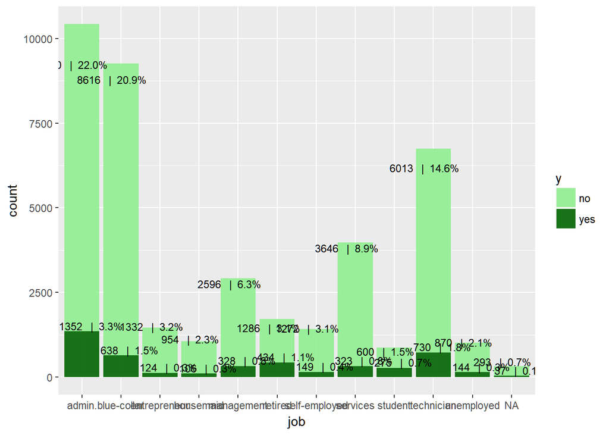

```r
ggplot(bank_additional_full, aes(x=job, fill=y))  + geom_bar(alpha=0.9) + scale_fill_manual( values = c("light green","dark green")) +  geom_text(aes(label=paste(..count..,scales::percent(..count../sum(..count..)),sep = "   |  ")),stat='count',position=position_dodge(0.9),vjust=-0.2,size = 3)
```

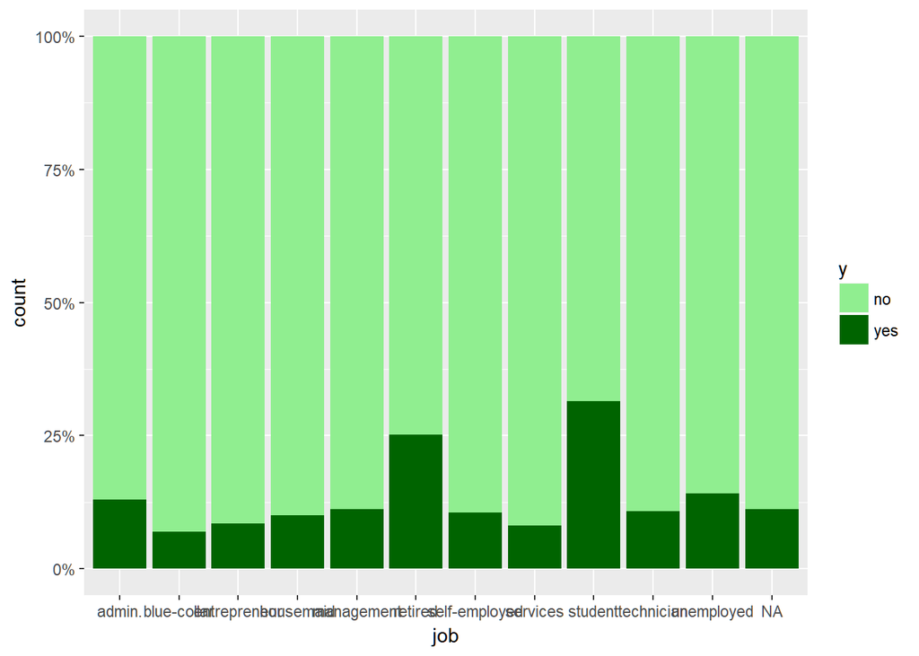

```r
# Build plot
ggplot(bank_additional_full, aes(job, fill = y)) +
  geom_bar(position = "fill") +
  scale_fill_manual( values = c("light green","dark green")) +
  scale_y_continuous(labels = scales::percent)
```

```r
crosstable <- table(bank_additional_full$job, bank_additional_full$y)
chisq.test(crosstable)
```

```
##
##  Pearson's Chi-squared test
##
## data:  crosstable
## X-squared = 961.21, df = 10, p-value < 2.2e-16
```

# Education

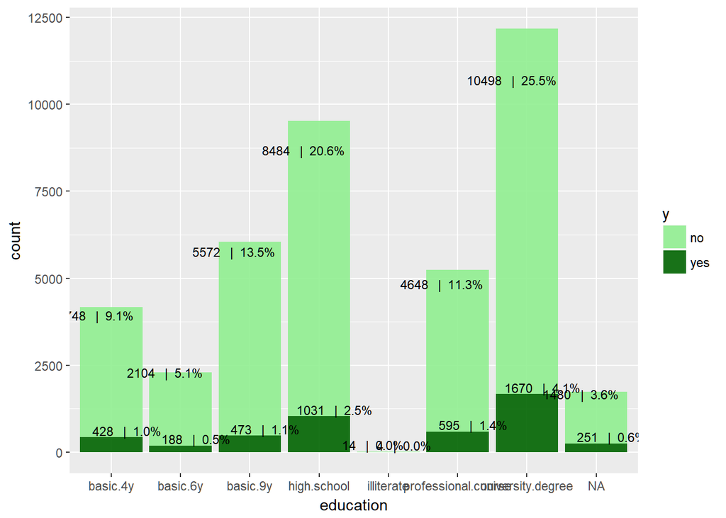

```r
ggplot(bank_additional_full, aes(x=education, fill=y))  + geom_bar(alpha=0.9) + scale_fill_manual( values = c("light green","dark green")) +  geom_text(aes(label=paste(..count..,scales::percent(..count../sum(..count..)),sep = "   |  ")),stat='count',position=position_dodge(0.9),vjust=-0.2,size = 3)
```

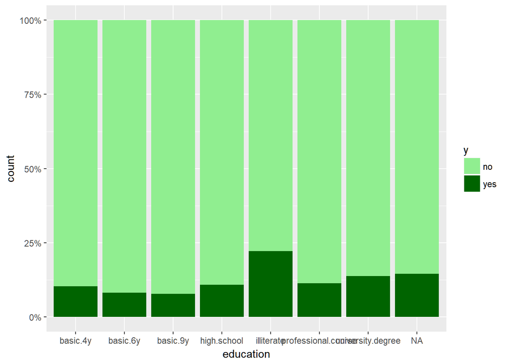

```r
# Build plot
ggplot(bank_additional_full, aes(education, fill = y)) +
  geom_bar(position = "fill") +
  scale_fill_manual( values = c("light green","dark green")) +
  scale_y_continuous(labels = scales::percent)
```

```r
crosstable <- table(bank_additional_full$education, bank_additional_full$y)
chisq.test(crosstable)
```

```
##
##  Pearson's Chi-squared test
##
## data:  crosstable
## X-squared = 176.13, df = 6, p-value < 2.2e-16
```

# Housing

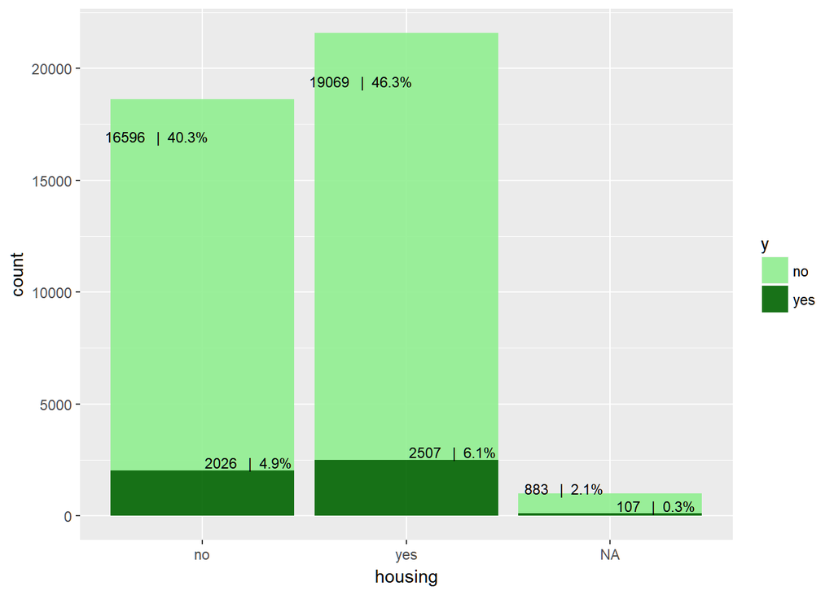

```r
ggplot(bank_additional_full, aes(x=housing, fill=y))  + geom_bar(alpha=0.9) + scale_fill_manual( values = c("light green","dark green")) +  geom_text(aes(label=paste(..count..,scales::percent(..count../sum(..count..)),sep = "   |  ")),stat='count',position=position_dodge(0.9),vjust=-0.2,size = 3)
```

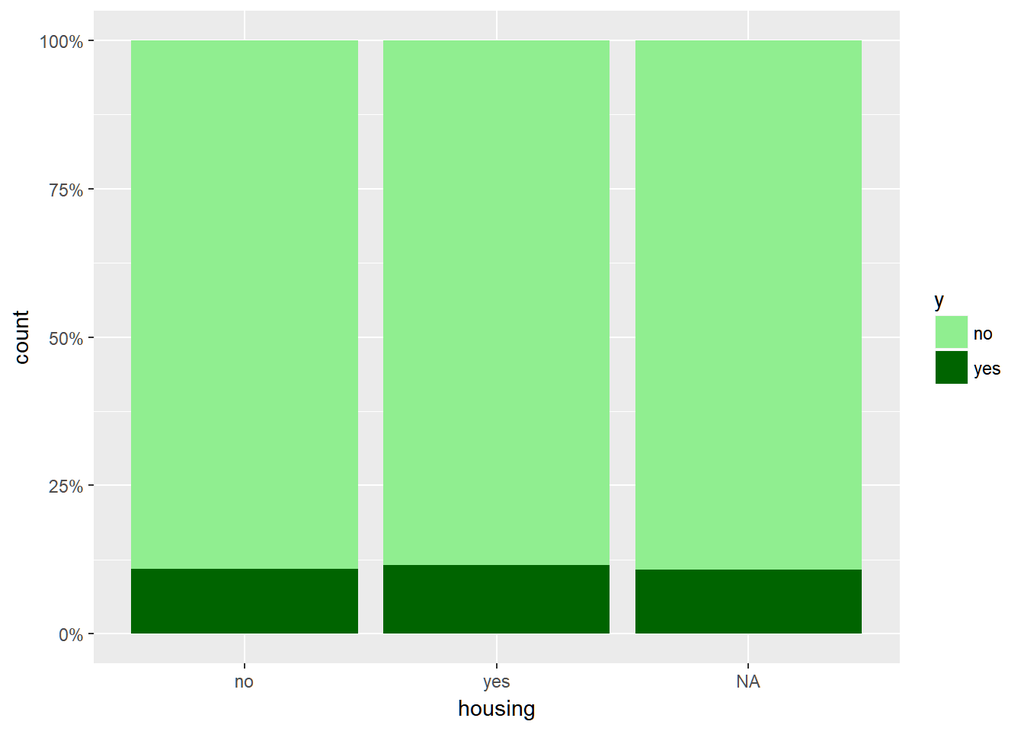

```r
# Build plot
ggplot(bank_additional_full, aes(housing, fill = y)) +
  geom_bar(position = "fill") +
  scale_fill_manual( values = c("light green","dark green")) +
  scale_y_continuous(labels = scales::percent)
```

```r
crosstable <- table(bank_additional_full$housing, bank_additional_full$y)
chisq.test(crosstable)
```

```
##
##  Pearson's Chi-squared test with Yates' continuity correction
##
## data:  crosstable
## X-squared = 5.3938, df = 1, p-value = 0.02021
```

# Loan

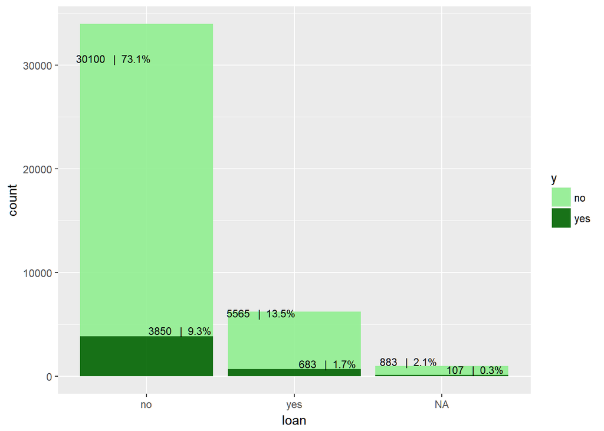

```r
ggplot(bank_additional_full, aes(x=loan, fill=y))  + geom_bar(alpha=0.9) + scale_fill_manual( values = c("light green","dark green")) +  geom_text(aes(label=paste(..count..,scales::percent(..count../sum(..count..)),sep = "   |  ")),stat='count',position=position_dodge(0.9),vjust=-0.2,size = 3)
```

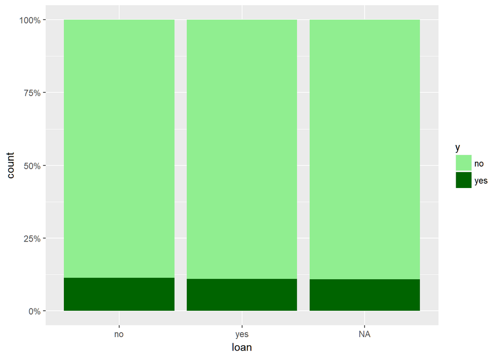

```r
# Build plot
ggplot(bank_additional_full, aes(loan, fill = y)) +
  geom_bar(position = "fill") +
  scale_fill_manual( values = c("light green","dark green")) +
  scale_y_continuous(labels = scales::percent)
```

```r
crosstable <- table(bank_additional_full$loan, bank_additional_full$y)
chisq.test(crosstable)
```

```
##
##  Pearson's Chi-squared test with Yates' continuity correction
##
## data:  crosstable
## X-squared = 0.84064, df = 1, p-value = 0.3592
```